# Text Analysis of the Marvel Cinematic Universe (MCU)

Aaron Giddings

12 Dec 2019

## Building the Database

What started off as an analysis of Ant-Man and the Wasp in an attempt to see how much important the word ‘quantum’ is to the script, this project became a comprehensive text analysis of the Marvel Cinematic Universe (MCU) to get a sense of the importance of certain words and characters as well as a sentiment analysis of certain movies, groups of movies (i.e. the Captain America Trilogy), phases, and the MCU as a whole.

NOTE: The entire MCU includes all of the movies up to Ant-Man and the Wasp, it does NOT include Captain Marvel, Avengers: Endgame, or Spider-Man: Far From Home.

```r
pacman::p_load(pdftools,     # extract content from PDF documents
               XML,          # Working with XML formatted data
               here,         # References for file paths
               countrycode,  # Working with names of countries
               tibble,       # Creating and manipulating tibbles
               stringr,      # Tools for qualitative data
               DT)
pacman::p_load(tm,
               pdftools,
               here,
               tau,
               tidyverse,
               stringr,
               tidytext,
               RColorBrewer,
               qdapRegex,
               qdapDictionaries,
               qdapTools,
               data.table,
               scales,
               harrypotter,
               text2vec,
               SnowballC,
               DT,
               quanteda,
               broom,
               tokenizers,
               grid,
               knitr,
               widyr)
```

Above are the packages I installed for the initial step of reading in the data, tokenizing the data, and obtaining a general count of the important words for the scripts.

```r
root <- rprojroot::find_root(rprojroot::is_rstudio_project)
dest3 <- file.path(root,'student_project_folders','oper655_fa2019_giddings','MCU Scripts', 'Phase 3')
dest2 <- file.path(root,'student_project_folders','oper655_fa2019_giddings','MCU Scripts', 'Phase 2')
dest1 <- file.path(root,'student_project_folders','oper655_fa2019_giddings','MCU Scripts', 'Phase 1')

mcu_phase3 <- list.files(dest3,
                           pattern = 'pdf',
                           full.names = TRUE)
mcu_phase2 <- list.files(dest2,
                         pattern = 'pdf',
                         full.names = TRUE)
mcu_phase1 <- list.files(dest1,
                         pattern = 'pdf',
                         full.names = TRUE)

#Attempting to add the rest of the scripts of the MCU into a corpus.
for (i in 1:8) {
  nam <- paste("tb_pdftools_mcu3",i,sep = "")
  assign(nam,pdftools::pdf_text(pdf = mcu_phase3[i]))
}
for (i in 1:6) {
  nam <- paste("tb_pdftools_mcu2",i,sep = "")
  assign(nam,pdftools::pdf_text(pdf = mcu_phase2[i]))
}
for (i in 1:6) {
  nam <- paste("tb_pdftools_mcu1",i,sep = "")
  assign(nam,pdftools::pdf_text(pdf = mcu_phase1[i]))
}
```

In the section above, I put all of the scripts of the MCU that I was able to download and assigned them to their own variable.

The section below assigns the variables that each script was assigned to and unpacks the text within the script to its own variable (text) within its own tibble. I added variables to identify the sequence each movie is within the MCU (i.e. Iron Man is the first movie within the MCU), what phase each movie belongs to, their release date, their director, their screenwriter(s), and their producer(s).

```r
#Phase 1 Movies
text_CaptAmerica <- tibble::tibble(title = "Captain America: The First Avenger",
                                   chapter = base::seq_along(tb_pdftools_mcu11),
                                    text = tb_pdftools_mcu11,
                                   movie_number = 5,
                                   mcu_phase = 1,
                                   release_date = "June 22, 2011",
                                   director = "Joe Johnston",
                                   screenwriter = "Christopher Markus & Stephen McFeely",
                                   producer = "Kevin Feige")
text_IronMan2 <- tibble::tibble(title = "Iron Man 2",
                                chapter = base::seq_along(tb_pdftools_mcu12),
                                text = tb_pdftools_mcu12,
                                movie_number = 3,
                                mcu_phase = 1,
                                release_date = "May 7, 2010",
                                director = "Jon Favreau",
                                screenwriter = "Justin Theroux",
                                producer = "Kevin Feige")
text_IronMan <- tibble::tibble(title = "Iron Man",
                               chapter = base::seq_along(tb_pdftools_mcu13),
                                text = tb_pdftools_mcu13,
                               movie_number = 1,
                               mcu_phase = 1,
                               release_date = "May 2, 2008",
                               director = "Jon Favreau",
                               screenwriter = "Mark Fergus, Hawk Ostby, Art Marcum, & Matt Holloway",
                               producer = "Kevin Feige & Avi Arad")
text_Avengers <- tibble::tibble(title = "The Avengers",
                               chapter = base::seq_along(tb_pdftools_mcu14),
                               text = tb_pdftools_mcu14,
                               movie_number = 6,
                               mcu_phase = 1,
                               release_date = "May 4, 2012",
                               director = "Joss Whedon",
                               screenwriter = "Joss Whedon",
                               producer = "Kevin Feige")
text_Hulk <- tibble::tibble(title = "The Incredible Hulk",
                            chapter = base::seq_along(tb_pdftools_mcu15),
                            text = tb_pdftools_mcu15,
                            movie_number = 2,
                            mcu_phase = 1,
                            release_date = "June 13, 2008",
                            director = "Louis Leterrier",
                            screenwriter = "Zak Penn",
                            producer = "Kevin Feige, Avi Arad, & Gale Anne Hurd")
text_Thor <- tibble::tibble(title = "Thor",
                            chapter = base::seq_along(tb_pdftools_mcu16),
                             text = tb_pdftools_mcu16,
                            movie_number = 4,
                            mcu_phase = 1,
                            release_date = "May 6, 2011",
                            director = "Kenneth Branagh",
                            screenwriter = "Ashley Edward Miller, Zack Stentz, & Don Payne",
                            producer = "Kevin Feige")
#Phase 2 Movies
text_AntMan <- tibble::tibble(title = "Ant-Man",
                              chapter = base::seq_along(tb_pdftools_mcu21),
                               text = tb_pdftools_mcu21,
                              movie_number = 12,
                              mcu_phase = 2,
                              release_date = "June 17, 2015",
                              director = "Peyton Reed",
                              screenwriter = "Edgar Wright, Joe Cornish, Adam McKay, & Paul Rudd",
                              producer = "Kevin Feige")
text_AvengersAOU <- tibble::tibble(title = "Avengers: Age of Ultron",
                                   chapter = base::seq_along(tb_pdftools_mcu22),
                                  text = tb_pdftools_mcu22,
                                  movie_number = 11,
                                  mcu_phase = 2,
                                  release_date = "May 1, 2015",
                                  director = "Joss Whedon",
                                  screenwriter = "Joss Whedon",
                                  producer = "Kevin Feige")
text_CaptAmerica2 <- tibble::tibble(title = "Captain America: The Winter Soldier",
                                    chapter = base::seq_along(tb_pdftools_mcu23),
                                    text = tb_pdftools_mcu23,
                                    movie_number = 9,
                                    mcu_phase = 2,
                                    release_date = "April 4, 2014",
                                    director = "Anthony & Joe Russo",
                                    screenwriter = "Christopher Markus & Stephen McFeely",
                                    producer = "Kevin Feige")
text_GotG <- tibble::tibble(title = "Guardians of the Galaxy",
                            chapter = base::seq_along(tb_pdftools_mcu24),
                             text = tb_pdftools_mcu24,
                            movie_number = 10,
                            mcu_phase = 2,
                            release_date = "August 1, 2014",
                            director = "James Gunn",
                            screenwriter = "James Gunn & Nicole Perlman",
                            producer = "Kevin Feige")
text_IronMan3 <- tibble::tibble(title = "Iron Man 3",
                                chapter = base::seq_along(tb_pdftools_mcu25),
                                text = tb_pdftools_mcu25,
                                movie_number = 7,
                                mcu_phase = 2,
                                release_date = "May 3, 2013",
                                director = "Shane Black",
                                screenwriter = "Drew Pearce & Shane Black",
                                producer = "Kevin Feige")
text_Thor2 <- tibble::tibble(title = "Thor: The Dark World",
                             chapter = base::seq_along(tb_pdftools_mcu26),
                             text = tb_pdftools_mcu26,
                             movie_number = 8,
                             mcu_phase = 2,
                             release_date = "November 8, 2013",
                             director = "Alan Taylor",
                             screenwriter = "Christopher L. Yost, Christopher Markus, & Stephen McFeely",
                             producer = "Kevin Feige")
#Phase 3 Movies (Ends at Ant-Man & The Wasp)
text_AntMan2 <- tibble::tibble(title = "Ant-Man & The Wasp",
                               chapter = base::seq_along(tb_pdftools_mcu31),
                          text = tb_pdftools_mcu31,
                          movie_number = 20,
                          mcu_phase = 3,
                          release_date = "July 6, 2018",
                          director = "Peyton Reed",
                          screenwriter = "Chris McKenna, Erik Sommers, Paul Rudd, Andrew Barrer, & Gabriel Ferrari",
                          producer = "Kevin Feige & Stephen Broussard")
text_AvengersIW <- tibble::tibble(title = "Avengers: Infinity War",
                                  chapter = base::seq_along(tb_pdftools_mcu32),
                               text = tb_pdftools_mcu32,
                               movie_number = 19,
                               mcu_phase = 3,
                               release_date = "April 27, 2018",
                               director = "Anthony & Joe Russo",
                               screenwriter = "Christopher Markus & Stephen McFeely",
                               producer = "Kevin Feige")
text_BkPanther <- tibble::tibble(title = "Black Panther",
                                 chapter = base::seq_along(tb_pdftools_mcu33),
                               text = tb_pdftools_mcu33,
                               movie_number = 18,
                               mcu_phase = 3,
                               release_date = "February 16, 2018",
                               director = "Ryan Coogler",
                               screenwriter = "Ryan Coogler & Joe Robert Cole",
                               producer = "Kevin Feige")
text_CaptAmerica3 <- tibble::tibble(title = "Captain America: Civil War",
                                    chapter = base::seq_along(tb_pdftools_mcu34),
                               text = tb_pdftools_mcu34,
                               movie_number = 13,
                               mcu_phase = 3,
                               release_date = "May 6, 2016",
                               director = "Anthony & Joe Russo",
                               screenwriter = "Christopher Markus & Stephen McFeely",
                               producer = "Kevin Feige")
text_DrStrange <- tibble::tibble(title = "Doctor Strange",
                                 chapter = base::seq_along(tb_pdftools_mcu35),
                               text = tb_pdftools_mcu35,
                               movie_number = 14,
                               mcu_phase = 3,
                               release_date = "November 4, 2016",
                               director = "Scott Derrickson",
                               screenwriter = "Jon Spaihts, Scott Derrickson, & C. Robert Cargill",
                               producer = "Kevin Feige")
text_GotG2 <- tibble::tibble(title = "Guardians of the Galaxy Volume 2",
                             chapter = base::seq_along(tb_pdftools_mcu36),
                               text = tb_pdftools_mcu36,
                             movie_number = 15,
                             mcu_phase = 3,
                             release_date = "May 5, 2017",
                             director = "James Gunn",
                             screenwriter = "James Gunn",
                             producer = "Kevin Feige")
text_SpiderManHC <- tibble::tibble(title = "Spider-Man: Homecoming",
                                   chapter = base::seq_along(tb_pdftools_mcu37),
                               text = tb_pdftools_mcu37,
                               movie_number = 16,
                               mcu_phase = 3,
                               release_date = "July 7, 2017",
                               director = "Jon Watts",
                               screenwriter = "Jonathan Goldstein, John Francis Daley, Jon Watts, Christopher Ford, Chris McKenna, & Erik Sommers",
                               producer = "Kevin Feige & Amy Pascal")
text_Thor3 <- tibble::tibble(title = "Thor: Ragnarok",
                             chapter = base::seq_along(tb_pdftools_mcu38),
                               text = tb_pdftools_mcu38,
                             movie_number = 17,
                             mcu_phase = 3,
                             release_date = "November 3, 2017",
                             director = "Taika Waititi",
                             screenwriter = "Eric Pearson, Craig Kyle, & Christopher L. Yost",
                             producer = "Kevin Feige")
```

## Initial Analysis

Some scripts that I found were cleaner than others. I made attempts to clean the worse ones using regular expressions using the code below with varying degrees of success. The cleaning I found most challenging was attempting to remove/replace apostrophes and words with apostrophes within the text. None of those attempts worked in removing apostrophes.

For each of the individual movies in the MCU, I concatonated all of the words to see which words appeared the most often removing common stop words that do not state any information. The following charts depict those results.

Below are the stop words that I attempted to add. NOTE: The ones with apostrophes did not work.

```r
stop_words <- rbind(stop_words, c("53", "SMART"))
stop_words <- rbind(stop_words, c("48", "SMART"))
stop_words <- rbind(stop_words, c("51", "SMART"))
stop_words <- rbind(stop_words, c("47", "SMART"))
stop_words <- rbind(stop_words, c("62", "SMART"))
stop_words <- rbind(stop_words, c("36", "SMART"))
stop_words <- rbind(stop_words, c("48", "SMART"))
stop_words <- rbind(stop_words, c("52", "SMART"))
stop_words <- rbind(stop_words, c("35", "SMART"))
stop_words <- rbind(stop_words, c("41", "SMART"))
stop_words <- rbind(stop_words, c("128", "SMART"))
stop_words <- rbind(stop_words, c("22", "SMART"))
stop_words <- rbind(stop_words, c("180", "SMART"))
stop_words <- rbind(stop_words, c("75", "SMART"))
stop_words <- rbind(stop_words, c("61", "SMART"))
stop_words <- rbind(stop_words, c("147", "SMART"))
stop_words <- rbind(stop_words, c("43", "SMART"))
stop_words <- rbind(stop_words, c("112", "SMART"))
stop_words <- rbind(stop_words, c("page", "SMART"))
stop_words <- rbind(stop_words, c("hey", "SMART"))
stop_words <- rbind(stop_words, c("yeah", "SMART"))
stop_words <- rbind(stop_words, c("cont'd", "SMART"))
stop_words <- rbind(stop_words, c("cont' d", "SMART"))
stop_words <- rbind(stop_words, c("int", "SMART"))
stop_words <- rbind(stop_words, c("gonna", "SMART"))
stop_words <- rbind(stop_words, c("gotta", "SMART"))
stop_words <- rbind(stop_words, c("wanna", "SMART"))
stop_words <- rbind(stop_words, c("revisions", "SMART"))
stop_words <- rbind(stop_words, c("10", "SMART"))
stop_words <- rbind(stop_words, c("26", "SMART"))
stop_words <- rbind(stop_words, c("03", "SMART"))
stop_words <- rbind(stop_words, c("16", "SMART"))
stop_words <- rbind(stop_words, c("20", "SMART"))
stop_words <- rbind(stop_words, c("05", "SMART"))
stop_words <- rbind(stop_words, c("4th", "SMART"))
stop_words <- rbind(stop_words, c("ext", "SMART"))
stop_words <- rbind(stop_words, c("uh", "SMART"))
stop_words <- rbind(stop_words, c("draft", "SMART"))
stop_words <- rbind(stop_words, c("xx", "SMART"))
stop_words <- rbind(stop_words, c("2", "SMART"))
stop_words <- rbind(stop_words, c("continued", "SMART"))
stop_words <- rbind(stop_words, c("marvel", "SMART"))
stop_words <- rbind(stop_words, c("studios", "SMART"))
stop_words <- rbind(stop_words, c("written", "SMART"))
stop_words <- rbind(stop_words, c("07", "SMART"))
stop_words <- rbind(stop_words, c("salmon", "SMART"))
stop_words <- rbind(stop_words, c("2007", "SMART"))
stop_words <- rbind(stop_words, c("consent", "SMART"))
stop_words <- rbind(stop_words, c("duplication", "SMART"))
stop_words <- rbind(stop_words, c("marvel's", "SMART"))
stop_words <- rbind(stop_words, c("omitted", "SMART"))
stop_words <- rbind(stop_words, c("it's", "SMART"))
stop_words <- rbind(stop_words, c("it' s", "SMART"))
stop_words <- rbind(stop_words, c("marvel' s", "SMART"))
stop_words <- rbind(stop_words, c("guys", "SMART"))
stop_words <- rbind(stop_words, c("guy", "SMART"))
```

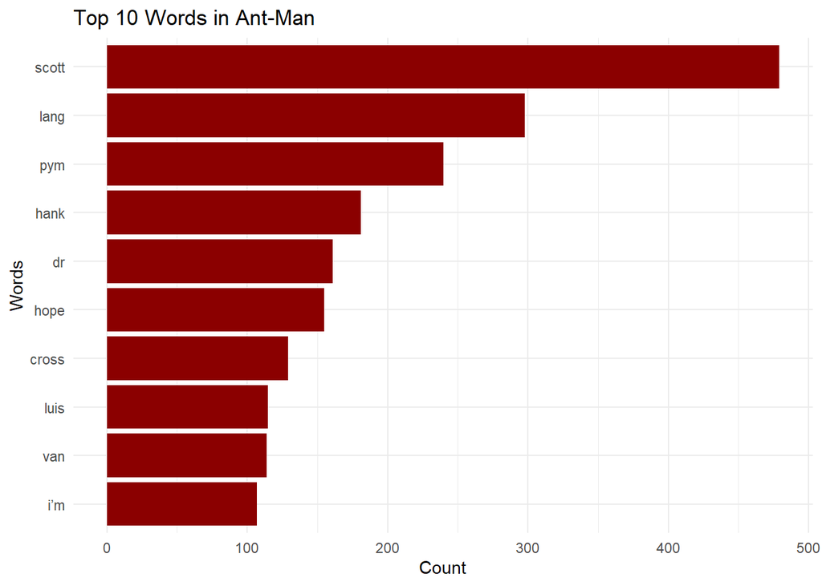

```r
#Top 10 words in a Bar Graph
#Ant-Man
am = text_AntMan %>%
  tidytext::unnest_tokens(word, text, token = 'words') %>%
  dplyr::anti_join(stop_words) %>%
  dplyr::count(word, sort = TRUE) %>%
  top_n(10)
pam <- ggplot(data=am, aes(x = reorder(word, n), y =n)) +
  geom_bar(stat="identity", fill="darkred") + coord_flip() +
  theme(legend.position="none") + theme_minimal() +
  labs(title = "Top 10 Words in Ant-Man") +
  xlab("Words") +
  ylab("Count")
pam
```

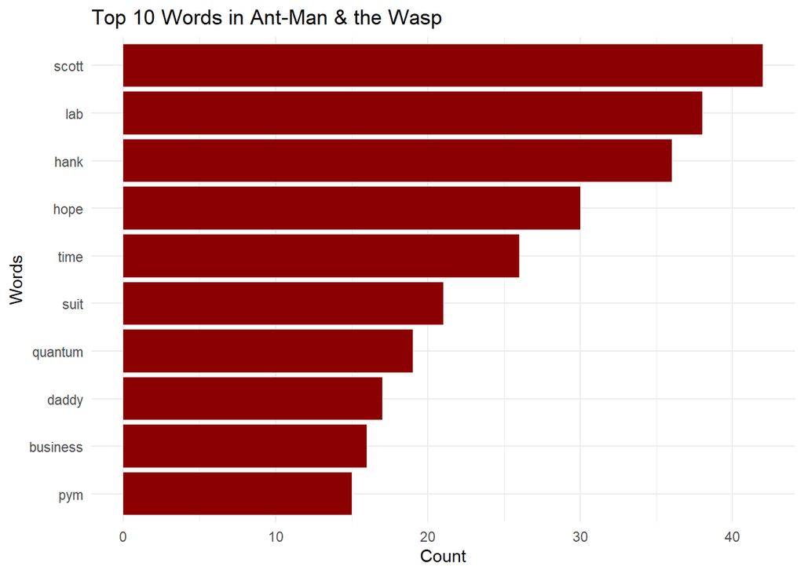

```r
#Ant-Man & the Wasp
am2 = text_AntMan2 %>%
  tidytext::unnest_tokens(word, text, token = 'words') %>%
  dplyr::anti_join(stop_words) %>%
  dplyr::count(word, sort = TRUE) %>%
  top_n(10)
pam2 <- ggplot(data=am2, aes(x = reorder(word, n), y =n)) +
  geom_bar(stat="identity", fill="darkred") + coord_flip() +
  theme(legend.position="none") + theme_minimal() +
  labs(title = "Top 10 Words in Ant-Man & the Wasp") +
  xlab("Words") +
  ylab("Count")
pam2
```

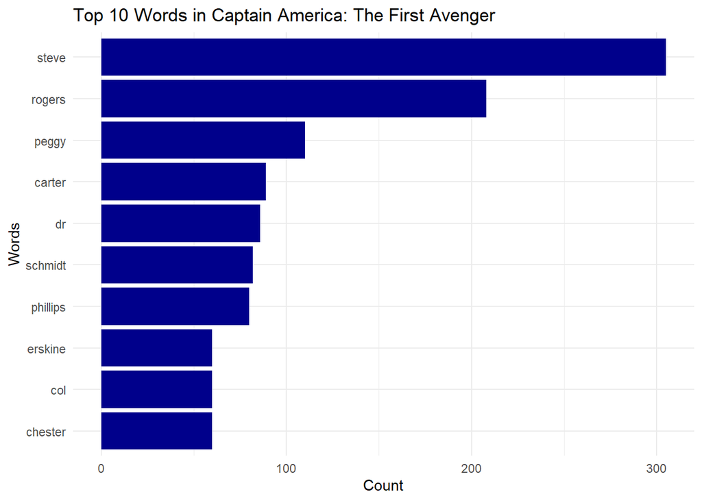

```r
#Captain America: The First Avenger
ca = text_CaptAmerica %>%
  tidytext::unnest_tokens(word, text, token = 'words') %>%
  dplyr::anti_join(stop_words) %>%
  dplyr::count(word, sort = TRUE) %>%
  top_n(10)
pca <- ggplot(data=ca, aes(x = reorder(word, n), y =n)) +
  geom_bar(stat="identity", fill="darkblue") + coord_flip() +
  theme(legend.position="none") + theme_minimal() +
  labs(title = "Top 10 Words in Captain America: The First Avenger") +
  xlab("Words") +
  ylab("Count")
pca
```

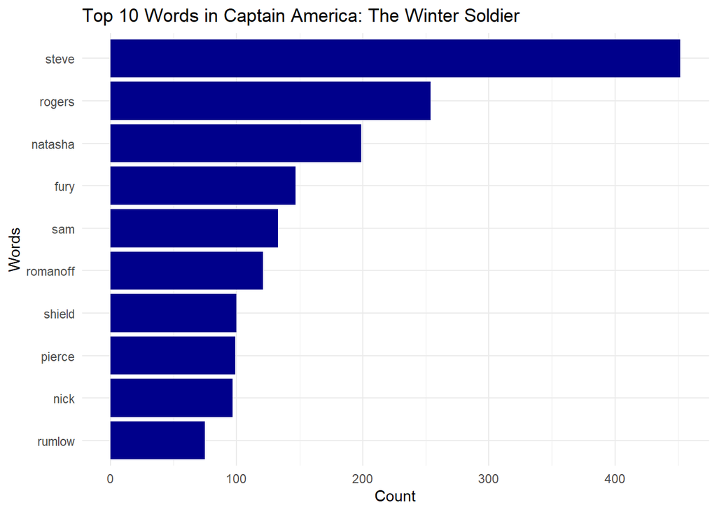

```r
#Captain America: The Winter Soldier
ca2 = text_CaptAmerica2 %>%
  tidytext::unnest_tokens(word, text, token = 'words') %>%
  dplyr::anti_join(stop_words) %>%
  dplyr::count(word, sort = TRUE) %>%
  top_n(10)
pca2 <- ggplot(data=ca2, aes(x = reorder(word, n), y =n)) +
  geom_bar(stat="identity", fill="darkblue") + coord_flip() +
  theme(legend.position="none") + theme_minimal() +
  labs(title = "Top 10 Words in Captain America: The Winter Soldier") +
  xlab("Words") +
  ylab("Count")
pca2
```

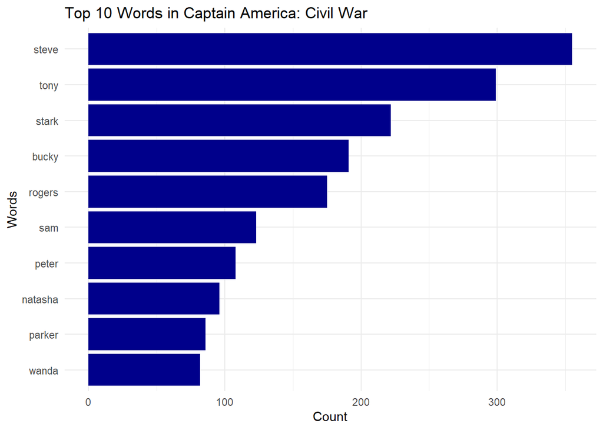

```r
#Captain America: Civil War
ca3 = text_CaptAmerica3 %>%
  tidytext::unnest_tokens(word, text, token = 'words') %>%
  dplyr::anti_join(stop_words) %>%
  dplyr::count(word, sort = TRUE) %>%
  top_n(10)
pca3 <- ggplot(data=ca3, aes(x = reorder(word, n), y =n)) +
  geom_bar(stat="identity", fill="darkblue") + coord_flip() +
  theme(legend.position="none") + theme_minimal() +
  labs(title = "Top 10 Words in Captain America: Civil War") +
  xlab("Words") +
  ylab("Count")
pca3
```

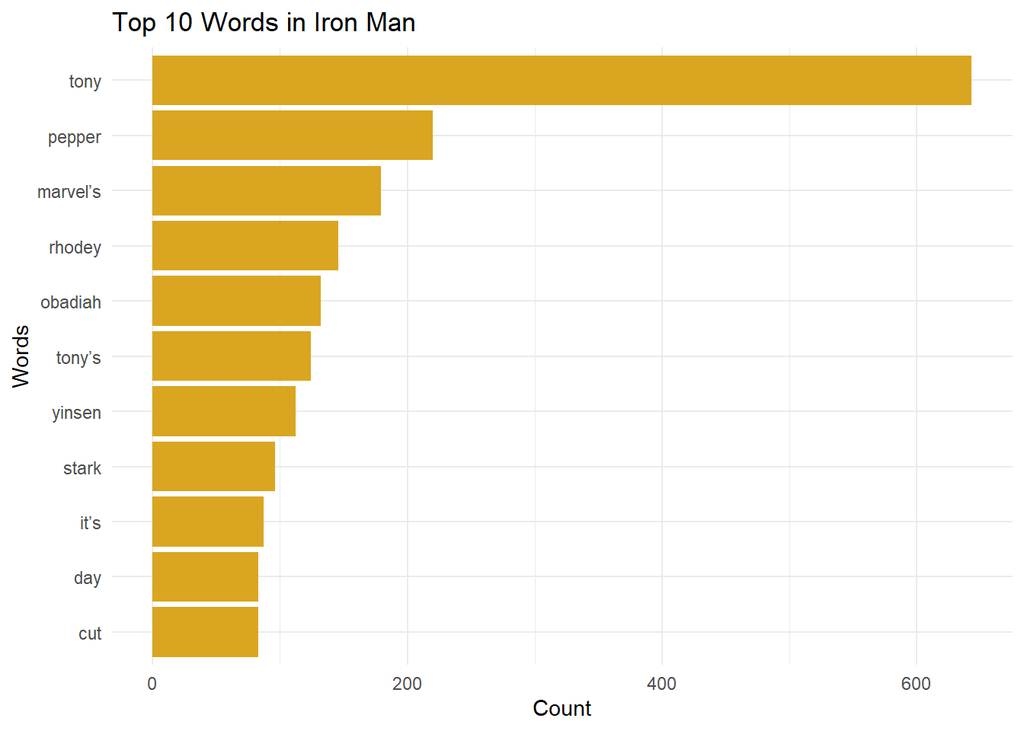

```r
#Iron Man
im = text_IronMan %>%
  tidytext::unnest_tokens(word, text, token = 'words') %>%
  dplyr::anti_join(stop_words) %>%
  dplyr::count(word, sort = TRUE) %>%
  top_n(10)
pim <- ggplot(data=im, aes(x = reorder(word, n), y =n)) +
  geom_bar(stat="identity", fill="goldenrod") + coord_flip() +
  theme(legend.position="none") + theme_minimal() +
  labs(title = "Top 10 Words in Iron Man") +
  xlab("Words") +
  ylab("Count")
pim
```

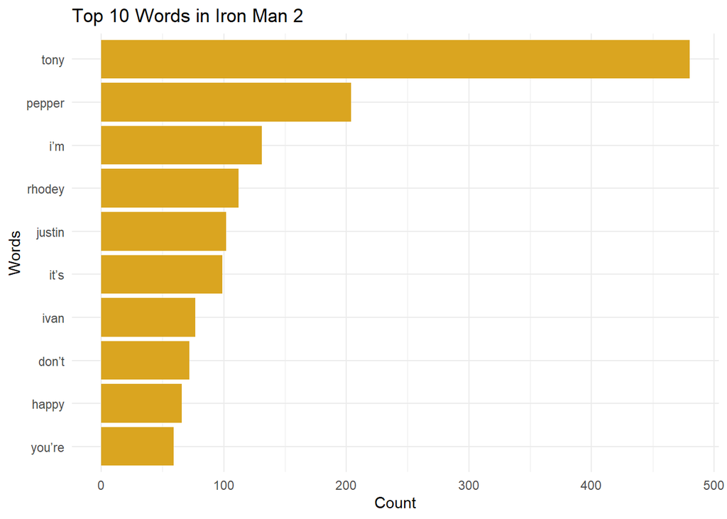

```r
#Iron Man 2
im2 = text_IronMan2 %>%
  tidytext::unnest_tokens(word, text, token = 'words') %>%
  dplyr::anti_join(stop_words) %>%
  dplyr::count(word, sort = TRUE) %>%
  top_n(10)
pim2 <- ggplot(data=im2, aes(x = reorder(word, n), y =n)) +
  geom_bar(stat="identity", fill="goldenrod") + coord_flip() +
  theme(legend.position="none") + theme_minimal() +
  labs(title = "Top 10 Words in Iron Man 2") +
  xlab("Words") +
  ylab("Count")
pim2
```

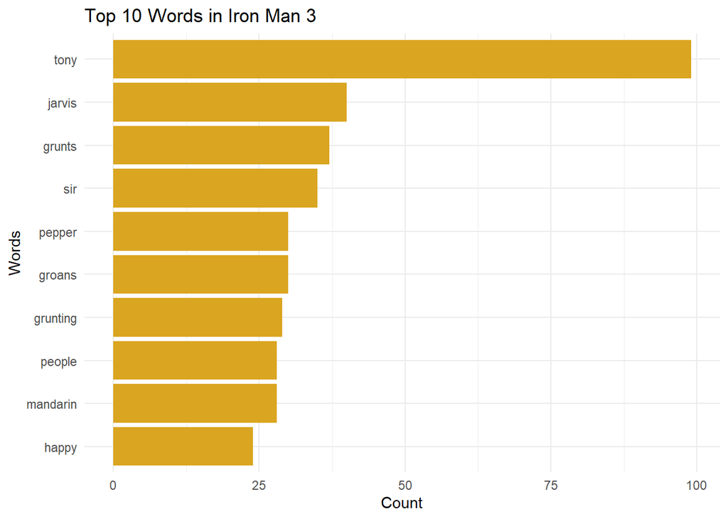

```r
#Iron Man 3
im3 = text_IronMan3 %>%
  tidytext::unnest_tokens(word, text, token = 'words') %>%
  dplyr::anti_join(stop_words) %>%
  dplyr::count(word, sort = TRUE) %>%
  top_n(10)
pim3 <- ggplot(data=im3, aes(x = reorder(word, n), y =n)) +
  geom_bar(stat="identity", fill="goldenrod") + coord_flip() +
  theme(legend.position="none") + theme_minimal() +
  labs(title = "Top 10 Words in Iron Man 3") +
  xlab("Words") +
  ylab("Count")
pim3
```

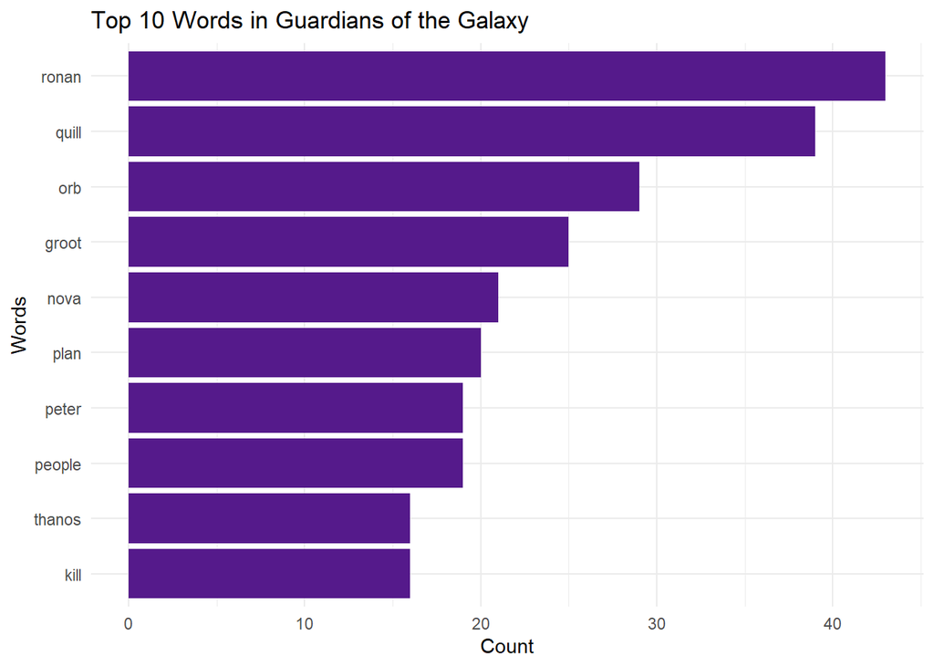

```r
#Guardians of the Galaxy
gotg = text_GotG %>%
  tidytext::unnest_tokens(word, text, token = 'words') %>%
  dplyr::anti_join(stop_words) %>%
  dplyr::count(word, sort = TRUE) %>%
  top_n(10)
pgotg <- ggplot(data=gotg, aes(x = reorder(word, n), y =n)) +
  geom_bar(stat="identity", fill="purple4") + coord_flip() +
  theme(legend.position="none") + theme_minimal() +
  labs(title = "Top 10 Words in Guardians of the Galaxy") +
  xlab("Words") +
  ylab("Count")
pgotg
```

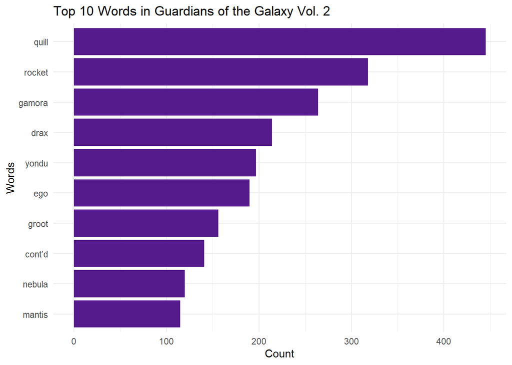

```r
#Guardians of the Galaxy Volume 2
gotg2 = text_GotG2 %>%
  tidytext::unnest_tokens(word, text, token = 'words') %>%
  dplyr::anti_join(stop_words) %>%
  dplyr::count(word, sort = TRUE) %>%
  top_n(10)
pgotg2 <- ggplot(data=gotg2, aes(x = reorder(word, n), y =n)) +
  geom_bar(stat="identity", fill="purple4") + coord_flip() +
  theme(legend.position="none") + theme_minimal() +
  labs(title = "Top 10 Words in Guardians of the Galaxy Vol. 2") +
  xlab("Words") +
  ylab("Count")
pgotg2
```

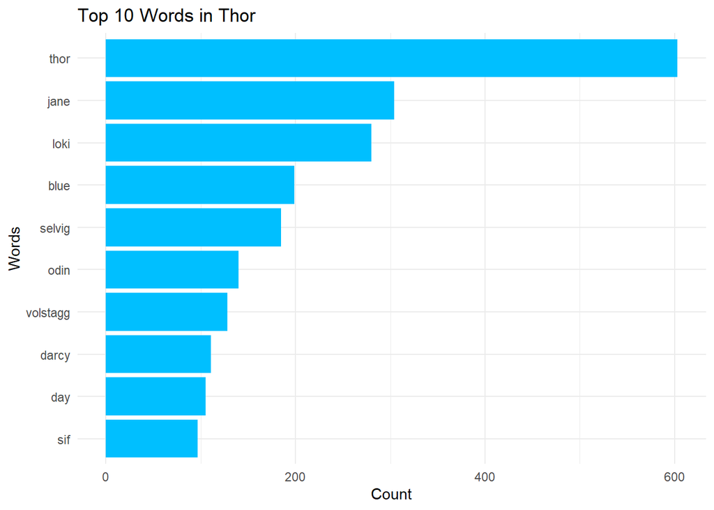

```r
#Thor
t = text_Thor %>%
  tidytext::unnest_tokens(word, text, token = 'words') %>%
  dplyr::anti_join(stop_words) %>%
  dplyr::count(word, sort = TRUE) %>%
  top_n(10)
pt <- ggplot(data=t, aes(x = reorder(word, n), y =n)) +
  geom_bar(stat="identity", fill="deepskyblue") + coord_flip() +
  theme(legend.position="none") + theme_minimal() +
  labs(title = "Top 10 Words in Thor") +
  xlab("Words") +
  ylab("Count")
pt
```

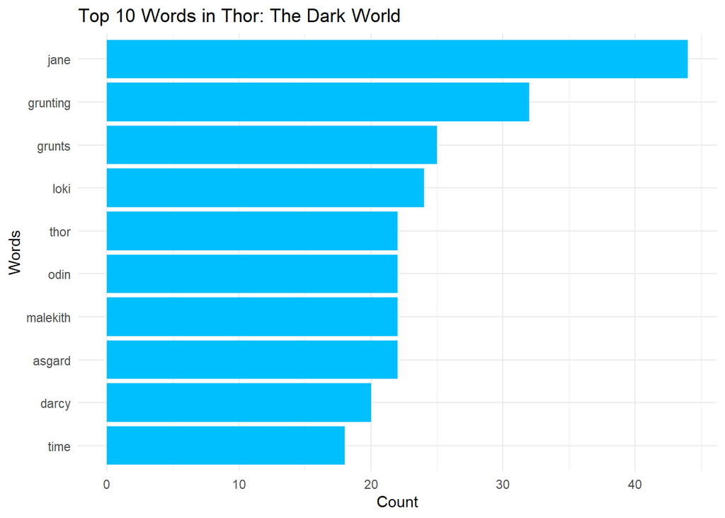

```r
#Thor: The Dark World
t2 = text_Thor2 %>%
  tidytext::unnest_tokens(word, text, token = 'words') %>%
  dplyr::anti_join(stop_words) %>%
  dplyr::count(word, sort = TRUE) %>%
  top_n(10)
pt2 <- ggplot(data=t2, aes(x = reorder(word, n), y =n)) +
  geom_bar(stat="identity", fill="deepskyblue") + coord_flip() +
  theme(legend.position="none") + theme_minimal() +
  labs(title = "Top 10 Words in Thor: The Dark World") +
  xlab("Words") +
  ylab("Count")
pt2
```

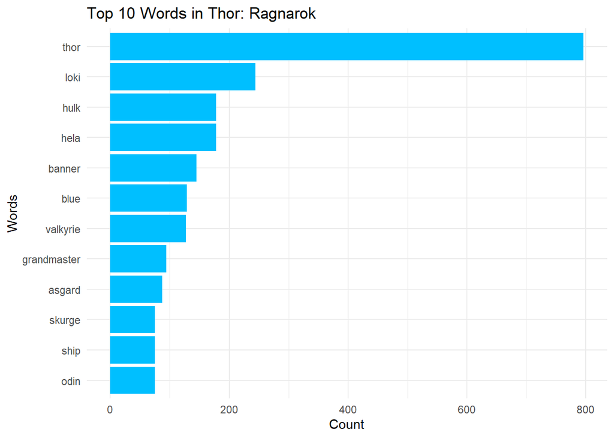

```r
#Thor: Ragnarok
t3 = text_Thor3 %>%
  tidytext::unnest_tokens(word, text, token = 'words') %>%
  dplyr::anti_join(stop_words) %>%
  dplyr::count(word, sort = TRUE) %>%
  top_n(10)
pt3 <- ggplot(data=t3, aes(x = reorder(word, n), y =n)) +
  geom_bar(stat="identity", fill="deepskyblue") + coord_flip() +
  theme(legend.position="none") + theme_minimal() +
  labs(title = "Top 10 Words in Thor: Ragnarok") +
  xlab("Words") +
  ylab("Count")
pt3
```

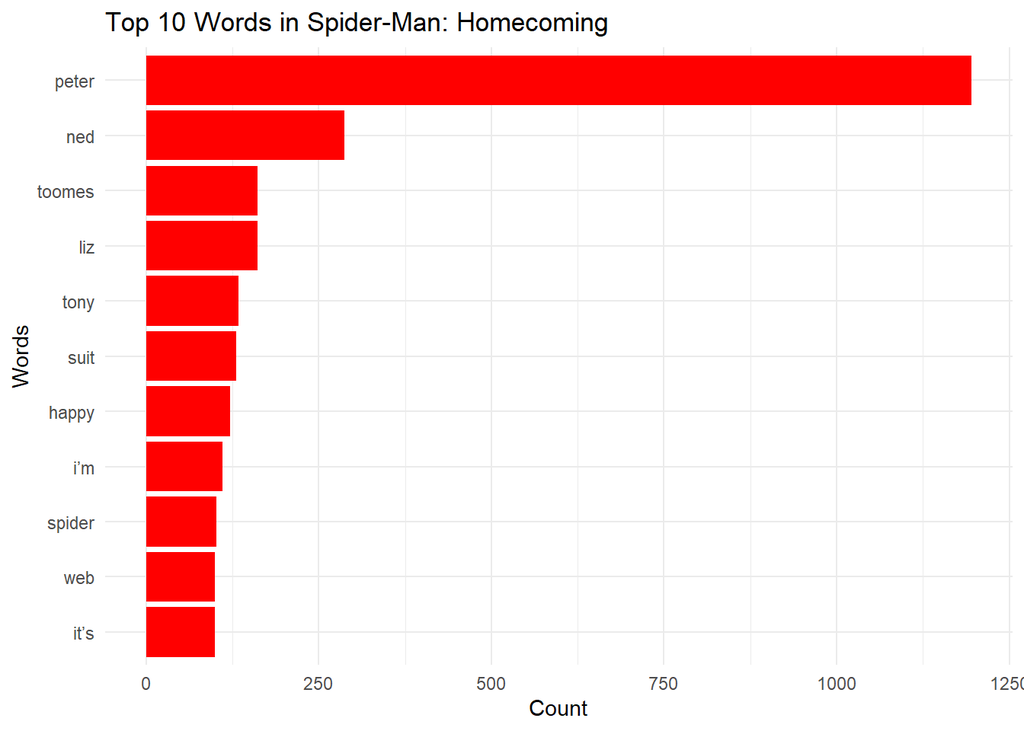

```r
#Spider-Man: Homecoming
sm = text_SpiderManHC %>%
  tidytext::unnest_tokens(word, text, token = 'words') %>%
  dplyr::anti_join(stop_words) %>%
  dplyr::count(word, sort = TRUE) %>%
  top_n(10)
psm <- ggplot(data=sm, aes(x = reorder(word, n), y =n)) +
  geom_bar(stat="identity", fill="red") + coord_flip() +
  theme(legend.position="none") + theme_minimal() +
  labs(title = "Top 10 Words in Spider-Man: Homecoming") +
  xlab("Words") +
  ylab("Count")
psm
```

[figure not shown]

```r
#The Incredible Hulk
h = text_Hulk %>%
  tidytext::unnest_tokens(word, text, token = 'words') %>%
  dplyr::anti_join(stop_words) %>%
  dplyr::count(word, sort = TRUE) %>%
  top_n(10)
ph <- ggplot(data=h, aes(x = reorder(word, n), y =n)) +
  geom_bar(stat="identity", fill="darkgreen") + coord_flip() +
  theme(legend.position="none") + theme_minimal() +
  labs(title = "Top 10 Words in The Incredible Hulk") +
  xlab("Words") +
  ylab("Count")
ph
```

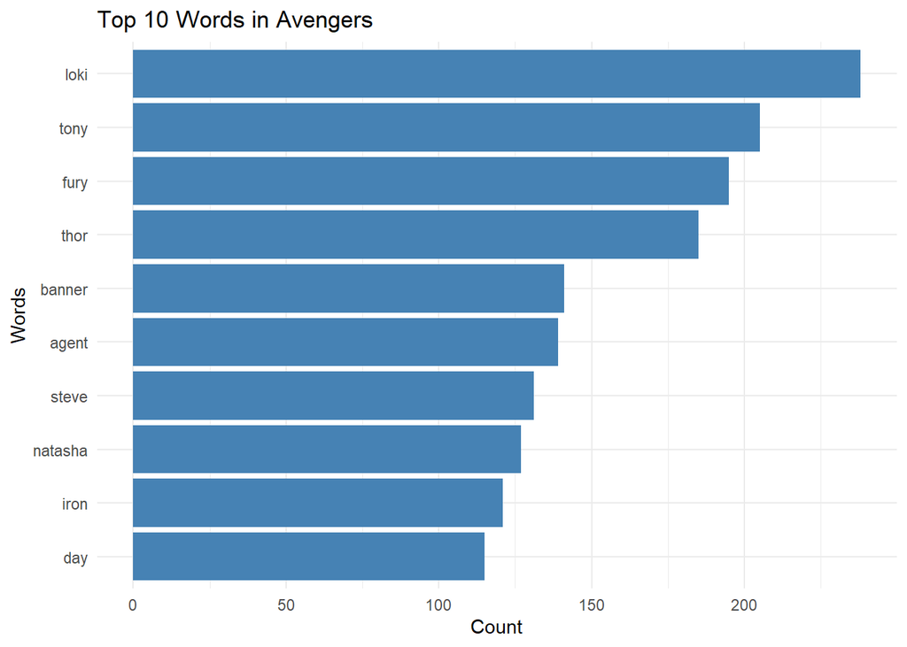

```r
#Avengers
av = text_Avengers %>%
  tidytext::unnest_tokens(word, text, token = 'words') %>%
  dplyr::anti_join(stop_words) %>%
  dplyr::count(word, sort = TRUE) %>%
  top_n(10)
pav <- ggplot(data=av, aes(x = reorder(word, n), y =n)) +
  geom_bar(stat="identity", fill="steelblue") + coord_flip() +
  theme(legend.position="none") + theme_minimal() +
  labs(title = "Top 10 Words in Avengers") +
  xlab("Words") +
  ylab("Count")
pav
```

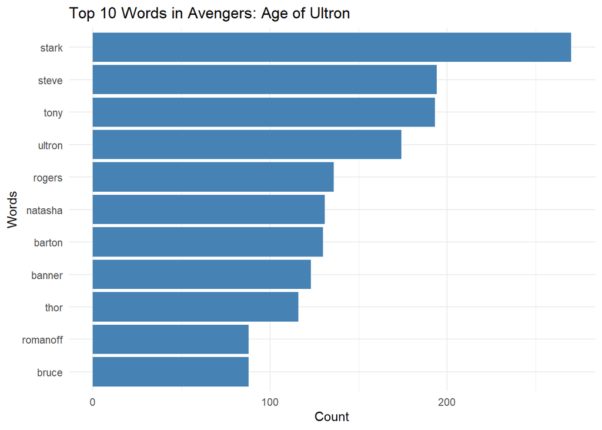

```r
#Avengers: Age of Ultron
av2 = text_AvengersAOU %>%
  tidytext::unnest_tokens(word, text, token = 'words') %>%
  dplyr::anti_join(stop_words) %>%
  dplyr::count(word, sort = TRUE) %>%
  top_n(10)
pav2 <- ggplot(data=av2, aes(x = reorder(word, n), y =n)) +
  geom_bar(stat="identity", fill="steelblue") + coord_flip() +
  theme(legend.position="none") + theme_minimal() +
  labs(title = "Top 10 Words in Avengers: Age of Ultron") +
  xlab("Words") +
  ylab("Count")
pav2
```

[figure not shown]

```r
#Avengers: Infinity War
av3 = text_AvengersIW %>%
  tidytext::unnest_tokens(word, text, token = 'words') %>%
  dplyr::anti_join(stop_words) %>%
  dplyr::count(word, sort = TRUE) %>%
  top_n(10)
pav3 <- ggplot(data=av3, aes(x = reorder(word, n), y =n)) +
  geom_bar(stat="identity", fill="steelblue") + coord_flip() +
  theme(legend.position="none") + theme_minimal() +
  labs(title = "Top 10 Words in Avengers: Infinity War") +
  xlab("Words") +
  ylab("Count")
pav3
```

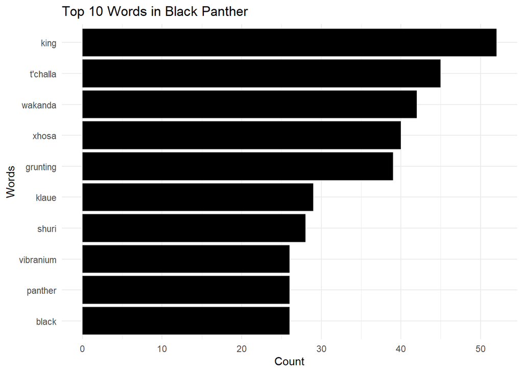

```r
#Black Panther
bp = text_BkPanther %>%
  tidytext::unnest_tokens(word, text, token = 'words') %>%
  dplyr::anti_join(stop_words) %>%
  dplyr::count(word, sort = TRUE) %>%
  top_n(10)
pbp <- ggplot(data=bp, aes(x = reorder(word, n), y =n)) +
  geom_bar(stat="identity", fill="black") + coord_flip() +
  theme(legend.position="none") + theme_minimal() +
  labs(title = "Top 10 Words in Black Panther") +
  xlab("Words") +
  ylab("Count")
pbp
```

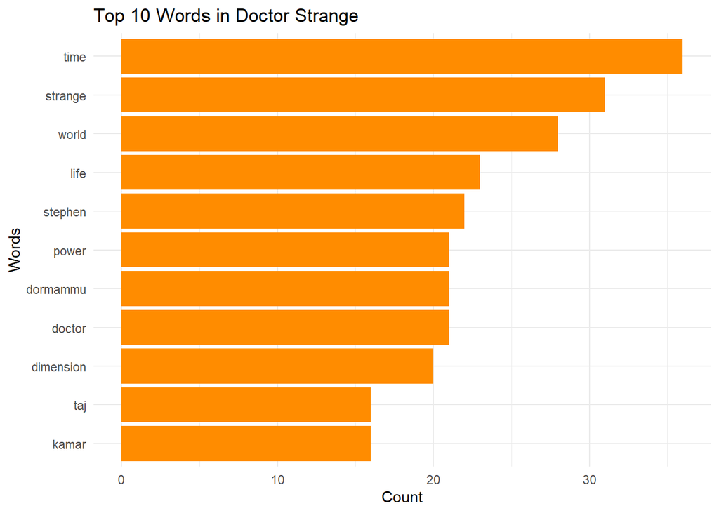

```r
#Doctor Strange
ds = text_DrStrange %>%
  tidytext::unnest_tokens(word, text, token = 'words') %>%
  dplyr::anti_join(stop_words) %>%
  dplyr::count(word, sort = TRUE) %>%
  top_n(10)
pds <- ggplot(data=ds, aes(x = reorder(word, n), y =n)) +
  geom_bar(stat="identity", fill="darkorange") + coord_flip() +
  theme(legend.position="none") + theme_minimal() +
  labs(title = "Top 10 Words in Doctor Strange") +
  xlab("Words") +
  ylab("Count")
pds
```

Below are the concatonations of the groups of movies, the phases, and the entire MCU.

```r
#Phase Tibbles
text_mcu_p1 <- rbind(text_IronMan,
                     text_CaptAmerica,
                     text_Hulk,
                     text_IronMan2,
                     text_Thor,
                     text_Avengers)
text_mcu_p2 <- rbind(text_IronMan3,
                     text_CaptAmerica2,
                     text_GotG,
                     text_AntMan,
                     text_Thor2,
                     text_AvengersAOU)
text_mcu_p3 <- rbind(text_SpiderManHC,
                     text_CaptAmerica3,
                     text_GotG2,
                     text_AntMan2,
                     text_Thor3,
                     text_AvengersIW,
                     text_BkPanther,
                     text_DrStrange)
#The entire MCU
text_mcu <- rbind(text_mcu_p1, text_mcu_p2, text_mcu_p3)
#Series Tibbles
text_AM_Comb <- rbind(text_AntMan, text_AntMan2)
text_GotG_Comb <- rbind(text_GotG, text_GotG2)
text_AV_Tril <- rbind(text_Avengers, text_AvengersAOU, text_AvengersIW)
text_CA_Tril <- rbind(text_CaptAmerica, text_CaptAmerica2, text_CaptAmerica3)
text_IM_Tril <- rbind(text_IronMan, text_IronMan2, text_IronMan3)
text_Thor_Tril <- rbind(text_Thor, text_Thor2, text_Thor3)
```

Below is the analysis of the various groups.

[figure not shown]

```r
#Cursory Analysis by Phase
#Phase 1
mcup1 = text_mcu_p1 %>%
  tidytext::unnest_tokens(word, text, token = 'words') %>%
  dplyr::anti_join(stop_words) %>%
  dplyr::count(word, sort = TRUE) %>%
  top_n(10)
pmcup1<-ggplot(data=mcup1, aes(x = reorder(word, n), y =n)) +
  geom_bar(stat="identity", fill="dodgerblue") + coord_flip() +
  theme(legend.position="none") + theme_minimal() +
  labs(title = "Top 10 Words in Phase 1 of the MCU") +
  xlab("Words") +
  ylab("Count")
pmcup1
```

[figure not shown]

```r
#Phase 2
mcup2 = text_mcu_p2 %>%
  tidytext::unnest_tokens(word, text, token = 'words') %>%
  dplyr::anti_join(stop_words) %>%
  dplyr::count(word, sort = TRUE) %>%
  top_n(10)
pmcup2<-ggplot(data=mcup2, aes(x = reorder(word, n), y =n)) +
  geom_bar(stat="identity", fill="dodgerblue2") + coord_flip() +
  theme(legend.position="none") + theme_minimal() +
  labs(title = "Top 10 Words in Phase 2 of the MCU") +
  xlab("Words") +
  ylab("Count")
pmcup2
```

[figure not shown]

```r
#Phase 3
mcup3 = text_mcu_p3 %>%
  tidytext::unnest_tokens(word, text, token = 'words') %>%
  dplyr::anti_join(stop_words) %>%
  dplyr::count(word, sort = TRUE) %>%
  top_n(10)
pmcup3<-ggplot(data=mcup3, aes(x = reorder(word, n), y =n)) +
  geom_bar(stat="identity", fill="dodgerblue4") + coord_flip() +
  theme(legend.position="none") + theme_minimal() +
  labs(title = "Top 10 Words in Phase 3 of the MCU") +
  xlab("Words") +
  ylab("Count")
pmcup3
```

[figure not shown]

```r
#The Entire MCU
mcu = text_mcu %>%
  tidytext::unnest_tokens(word, text, token = 'words') %>%
  dplyr::anti_join(stop_words) %>%
  dplyr::count(word, sort = TRUE) %>%
  top_n(10)
pmcu<-ggplot(data=mcu, aes(x = reorder(word, n), y =n)) +
  geom_bar(stat="identity", fill="black") + coord_flip() +
  theme(legend.position="none") + theme_minimal() +
  labs(title = "Top 10 Words in the Entire MCU") +
  xlab("Words") +
  ylab("Count")
pmcu
```

[figure not shown]

```r
#Cursory Analysis by Grouped Movies
#The Captain America Movies
catm = text_CA_Tril %>%
  tidytext::unnest_tokens(word, text, token = 'words') %>%
  dplyr::anti_join(stop_words) %>%
  dplyr::count(word, sort = TRUE) %>%
  top_n(10)
pcatm<-ggplot(data=catm, aes(x = reorder(word, n), y =n)) +
  geom_bar(stat="identity", fill="darkblue") + coord_flip() +
  theme(legend.position="none") + theme_minimal() +
  labs(title = "Top 10 Words in the Captain America Trilogy") +
  xlab("Words") +
  ylab("Count")
pcatm
```

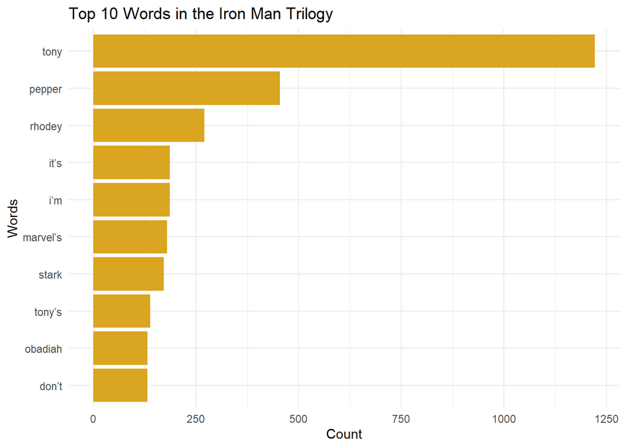

```r
#The Iron Man Movies
imtm = text_IM_Tril %>%
  tidytext::unnest_tokens(word, text, token = 'words') %>%
  dplyr::anti_join(stop_words) %>%
  dplyr::count(word, sort = TRUE) %>%
  top_n(10)
pimtm<-ggplot(data=imtm, aes(x = reorder(word, n), y =n)) +
  geom_bar(stat="identity", fill="goldenrod") + coord_flip() +
  theme(legend.position="none") + theme_minimal() +
  labs(title = "Top 10 Words in the Iron Man Trilogy") +
  xlab("Words") +
  ylab("Count")
pimtm
```

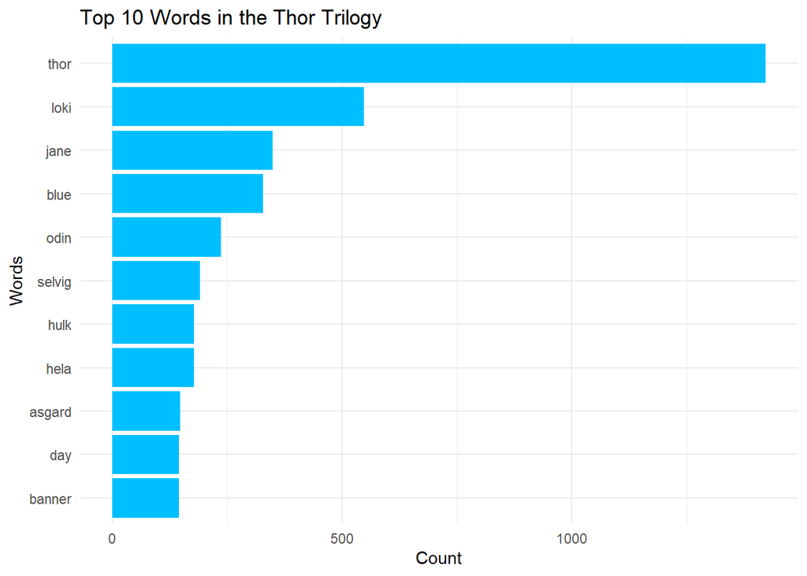

```r
#The Thor Movies
ttm = text_Thor_Tril %>%
  tidytext::unnest_tokens(word, text, token = 'words') %>%
  dplyr::anti_join(stop_words) %>%
  dplyr::count(word, sort = TRUE) %>%
  top_n(10)
pttm<-ggplot(data=ttm, aes(x = reorder(word, n), y =n)) +
  geom_bar(stat="identity", fill="deepskyblue") + coord_flip() +
  theme(legend.position="none") + theme_minimal() +
  labs(title = "Top 10 Words in the Thor Trilogy") +
  xlab("Words") +
  ylab("Count")
pttm
```

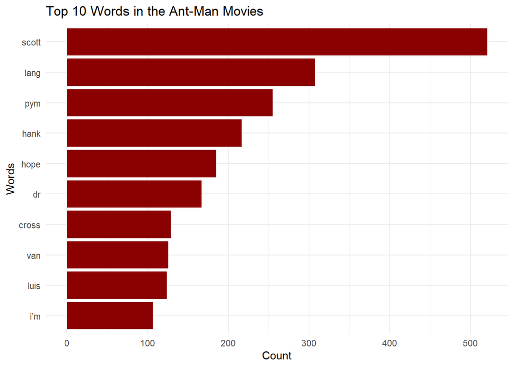

```r
#The Ant-Man Movies
acm = text_AM_Comb %>%
  tidytext::unnest_tokens(word, text, token = 'words') %>%
  dplyr::anti_join(stop_words) %>%
  dplyr::count(word, sort = TRUE) %>%
  top_n(10)
pacm <- ggplot(data=acm, aes(x = reorder(word, n), y =n)) +
  geom_bar(stat="identity", fill="darkred") + coord_flip() +
  theme(legend.position="none") + theme_minimal() +
  labs(title = "Top 10 Words in the Ant-Man Movies") +
  xlab("Words") +
  ylab("Count")
pacm
```

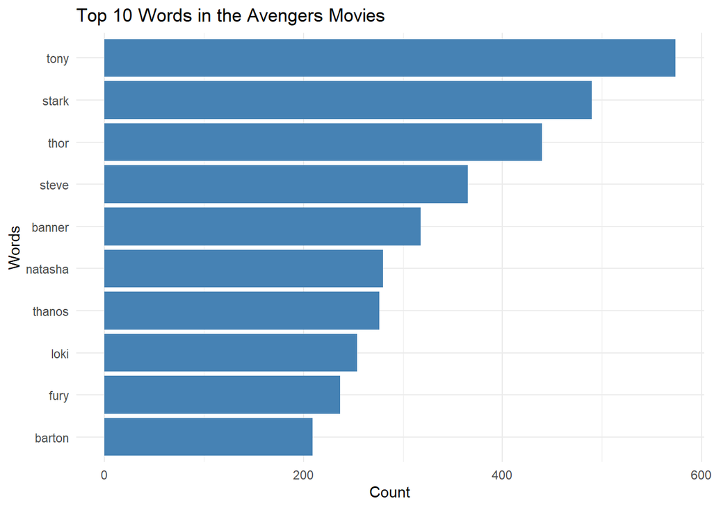

```r
#The Avengers Movies
avcm = text_AV_Tril %>%
  tidytext::unnest_tokens(word, text, token = 'words') %>%
  dplyr::anti_join(stop_words) %>%
  dplyr::count(word, sort = TRUE) %>%
  top_n(10)
pavcm<-ggplot(data=avcm, aes(x = reorder(word, n), y =n)) +
  geom_bar(stat="identity", fill="steelblue") + coord_flip() +
  theme(legend.position="none") + theme_minimal() +
  labs(title = "Top 10 Words in the Avengers Movies") +
  xlab("Words") +
  ylab("Count")
pavcm
```

[figure not shown]

```r
#The Guardians of the Galaxy Movies
gotgcm = text_GotG_Comb %>%
  tidytext::unnest_tokens(word, text, token = 'words') %>%
  dplyr::anti_join(stop_words) %>%
  dplyr::count(word, sort = TRUE) %>%
  top_n(10)
pgotgcm<-ggplot(data=gotgcm, aes(x = reorder(word, n), y =n)) +
  geom_bar(stat="identity", fill="purple4") + coord_flip() +
  theme(legend.position="none") + theme_minimal() +
  labs(title = "Top 10 Words in the Guardians of the Galaxy Movies") +
  xlab("Words") +
  ylab("Count")
pgotgcm
```

## Named Entity Recognition

Prior to conducting Named Entity Recognition (NER), the data must be parsed and extracted. The following code parses and extracts the text after calling the SpacyR library and initializing the environment.

```r
pacman::p_load(tidyr,
               tidytext,
               tidyverse,
               textdata,
               dplyr,
               stringr,
               ggplot2,
               magrittr,
               wordcloud,
               reshape2,
               quanteda,
               spacyr,
               NLP)

spacy_initialize()
mcu_data <- as.data.frame(text_mcu[1:9], stringsAsFactors = FALSE)
mcu_parsed <- spacy_parse(mcu_data$text, entity = TRUE)
mcu_extracted <- entity_extract(mcu_parsed)
```

The following code presents the different entities recognized and puts it in a histogram.

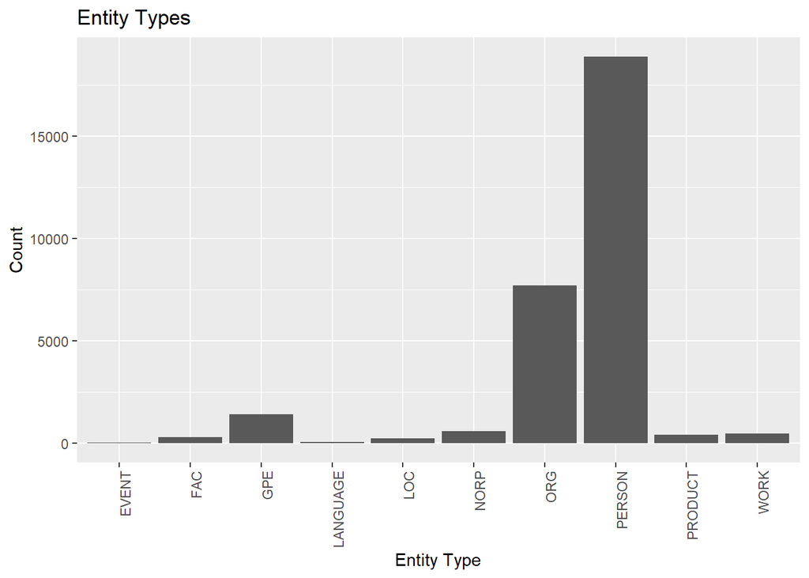

```r
#Entity Type Graph
mcu_extracted %>%
  filter(entity_type != "CARDINAL" & entity_type != "ORDINAL") %>%
  count(entity_type) %>%
  top_n(10) %>%
  ggplot(aes(x = entity_type, y = n)) +
  geom_bar(stat = "identity") +
  theme(axis.text.x = element_text(angle = 90, hjust = 1)) +
  labs(title = "Entity Types") +
  xlab("Entity Type") +
  ylab("Count")
```

I then checked the various entity types to see the accuracy of results. The most accurate one was ‘Person’. For a comparison, I am including the geopolitical entities (‘GPE’). The reason that Peter is mentioned so much is that there are two characters in the MCU that are named Peter (Peter Parker, and Peter Quill) and Tony Stark is in all of the Iron Man movies, one Captain America movie, the Spider-Man movie, and all of the Avengers movies.

[figure not shown]

```r
mcu_extracted %>%
  filter(entity_type == "PERSON" ) %>%
  group_by(entity_type) %>%
  count(entity) %>%
  top_n(10) %>%
  ggplot(aes(x = entity, y = n)) +
  geom_bar(stat = "identity") +
  theme(axis.text.x = element_text(angle = 90, hjust = 1)) +
  labs(title = "People") +
  xlab("People") +
  ylab("Mentions")
```

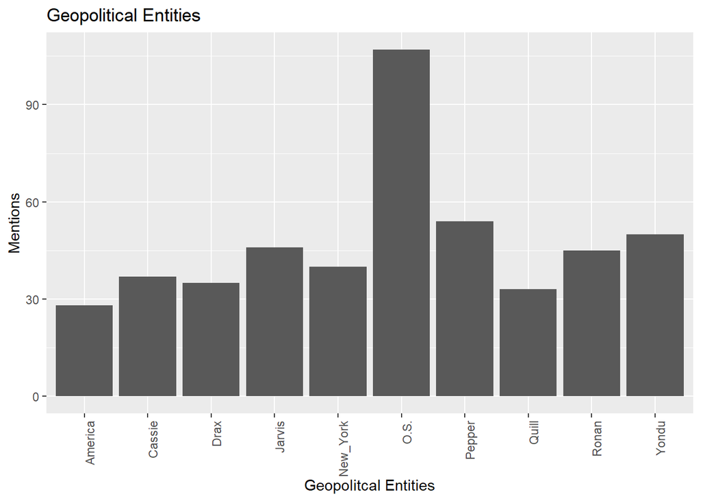

```r
#Geopolitical Entities in the MCU
mcu_extracted %>%
  filter(entity_type == "GPE" ) %>%
  group_by(entity_type) %>%
  count(entity) %>%
  top_n(10) %>%
  ggplot(aes(x = entity, y = n)) +
  geom_bar(stat = "identity") +
  theme(axis.text.x = element_text(angle = 90, hjust = 1))+
  labs(title = "Geopolitical Entities") +
  xlab("Geopolitcal Entities") +
  ylab("Mentions")
```

## Sentiment Analysis

After performing NER, I conducted sentiment analysis on the entire MCU. The initial analysis includes the top 10 positive words used and the top 10 negative words used in the entire MCU. Below are the packages used, unnesting the tokens, and the lexicons used to identify anger and joy.

```r
#Sentiment Analysis
pacman::p_load(tidyr,
               tidytext,
               tidyverse,
               textdata,
               dplyr,
               stringr,
               ggplot2,
               magrittr,
               wordcloud,
               reshape2,
               saotd)
nrc_joy <- get_sentiments("nrc") %>%
  filter(sentiment == "joy")
nrc_anger <- get_sentiments("nrc") %>%
  filter(sentiment == "anger")

mcu_unnested <- tidytext::unnest_tokens(text_mcu, word, text)
```

NOTE: I had to remove rocket and fury because those were character names and do not reflect sentiment.

```r
#Top 10 Positive Sentiment Words
mcu_unnested %>%
  anti_join(tibble::tibble(word = c("rocket")))%>%
  inner_join(nrc_joy) %>%
  count(word, sort = T)
```

```
# A tibble: 385 x 2
   word        n
   <chr>   <int>
 1 good      414
 2 happy     238
 3 hope      232
 4 god       169
 5 love      119
 6 green     116
 7 kind      115
 8 finally   106
 9 friend    101
10 found      88
# ... with 375 more rows
```

```r
#Top 10 Negative Sentiment Words
mcu_unnested %>%
  anti_join(tibble::tibble(word = c("rocket", "fury")))%>%
  inner_join(nrc_anger) %>%
  count(word, sort = T)
```

```
# A tibble: 592 x 2
   word        n
   <chr>   <int>
 1 soldier   176
 2 fight     165
 3 stone     153
 4 hell      152
 5 cross     145
 6 gun       128
 7 bad       109
 8 hit       102
 9 death      85
10 blast      84
# ... with 582 more rows
```

The next section ranks the top 10 most positive and top 10 most negative movies within the MCU. In order to obtain those values, I added the total words identified as positive and divide it by the total words identified as positive or negative (positive/ (positive + negative)). For the top 10 most negative movies used total number of negative words over total number of negative words or positive words (negative / (positive + negative)).

```r
#Top 10 Most Positive Movies in the MCU
mcu_unnested %>%
  inner_join(get_sentiments("bing")) %>%
  count(index = title, sentiment) %>%
  spread(sentiment, n, fill = 0) %>%
  mutate(sentiment = (positive/(positive + negative))) %>%
  top_n(10) %>%
  arrange(desc(sentiment)) %>%
  ungroup()
```

```
# A tibble: 10 x 4
   index                              negative positive sentiment
   <chr>                                 <dbl>    <dbl>     <dbl>
 1 Iron Man 2                              433      621     0.589
 2 Black Panther                           215      284     0.569
 3 Ant-Man & The Wasp                      287      366     0.560
 4 Iron Man 3                              394      491     0.555
 5 Spider-Man: Homecoming                  770      868     0.530
 6 Ant-Man                                 425      433     0.505
 7 Thor: The Dark World                    220      218     0.498
 8 Captain America: The First Avenger      340      332     0.494
 9 Doctor Strange                          292      256     0.467
10 Iron Man                                865      732     0.458
```

```r
#Top 10 Most Negative Movies in the MCU
mcu_unnested %>%
  inner_join(get_sentiments("bing")) %>%
  count(index = title, sentiment) %>%
  spread(sentiment, n, fill = 0) %>%
  mutate(sentiment = (negative/(positive + negative))) %>%
  top_n(10) %>%
  arrange(desc(sentiment)) %>%
  ungroup()
```

```
# A tibble: 10 x 4
   index                               negative positive sentiment
   <chr>                                  <dbl>    <dbl>     <dbl>
 1 Captain America: The Winter Soldier      606      323     0.652
 2 The Avengers                             889      481     0.649
 3 Avengers: Infinity War                  1082      595     0.645
 4 Avengers: Age of Ultron                  726      422     0.632
 5 Captain America: Civil War               779      458     0.630
 6 Thor                                    1086      691     0.611
 7 The Incredible Hulk                      921      595     0.608
 8 Thor: Ragnarok                           930      677     0.579
 9 Guardians of the Galaxy                  307      247     0.554
10 Guardians of the Galaxy Volume 2         847      699     0.548
```

The next section composes a word cloud of the most used words in the MCU and the most used words organized by sentiment.

[figure not shown]

```r
#Word Cloud - Most Used Words
mcu_unnested %>%
  anti_join(stop_words) %>%
  count(word) %>%
  with(wordcloud(word, n, max.words = 100))
```

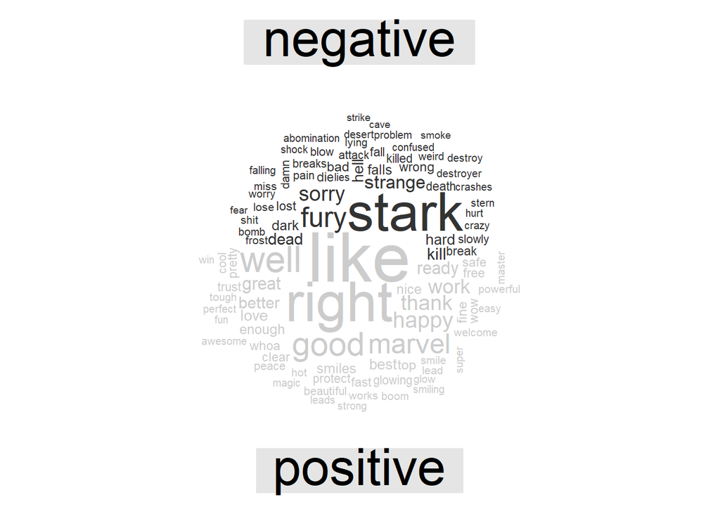

```r
#Word Cloud w/ Sentiment
mcu_unnested %>%
  inner_join(get_sentiments("bing")) %>%
  count(word, sentiment, sort = TRUE) %>%
  acast(word ~ sentiment, value.var = "n", fill = 0) %>%
  comparison.cloud(colors = c("gray20","gray80"),
                   max.words = 100)
```